# CUSTOMER DATA ANALYSIS

### Business Insights using RFM Analysis

[figure not shown]

PROJECT OVERVIEW

A mid-sized Indian retail company wants to analyze its customer base to improve targeted marketing, retain valuable customers, and detect patterns in customer behavior. You have been hired as a data analyst to clean, process, and analyze the customer transaction data to generate actionable insights.

**Your goal is to:**

- Assess customer demographics and transaction behavior.
- Clean and prepare the data for analysis.
- Conduct RFM (Recency, Frequency, Monetary) analysis.
- Visualize key patterns using charts.

**Key Goals:**

- Detect incomplete, inconsistent, or duplicate customer records and improve data quality, if applicable.
- Segment customers based on demographics and purchase behavior.
- Identify high-value customers using Recency-Frequency-Monetary (RFM) analysis.
- Visualize customer distribution across geographies, age groups, or income brackets.
- Generate actionable insights for marketing department.

ANALYTICAL WORKFLOW

This analysis is based on two datasets: **Customer Master Data** and **Customer Transaction Data**. The initial stages of the analysis are performed separately on each dataset to ensure better understanding, data quality, and clarity. Once the data is cleaned and structured, both datasets are combined to perform **RFM (Recency, Frequency, Monetary) analysis** and generate meaningful business insights through visualization.

1. Loading the data
2. Inspection of the datasets
3. Cleaning of the data
4. Exploratory Data Analysis
5. RFM Analysis
6. Data Visualization

DATASET 1 - CUSTOMER MASTER DATA ANALYSIS

🔹Importing all the required libraries for Data Analysis & Visualization

```python
import pandas as pd
import numpy as np
import matplotlib.pyplot as plt
import seaborn as sns
```

🔹Loading the Data

```python
customer = pd.read_csv("Customer_Master_Data.csv",encoding = "latin1")
```

🔹Inspection of the Data

**Shape preview of the Customer Master Dataset :**

```python
print("Shape :", customer.shape)
```

```
Shape : (1000, 9)
```

```python
customer.head()
```

|  | CustomerID | Name | Email | Gender | Age | City | MaritalStatus | NumChildren | JoinDate |
| --- | --- | --- | --- | --- | --- | --- | --- | --- | --- |
| 0 | CUST10000 | Onkar Bhargava | pkeer@yahoo.com | Male | 54 | Delhi | Divorced | 0 | 22-02-2021 |
| 1 | CUST10001 | Divit Kohli | mkalita@sarin.com | Female | 48 | Kolkata | Married | 0 | 06-12-2023 |
| 2 | CUST10002 | Kiara Behl | apteanay@hotmail.com | Male | 75 | Kolkata | Widowed | 2 | 23-08-2023 |
| 3 | CUST10003 | Vaibhav Sankar | bseshadri@choudhry.info | Male | 62 | Pune | Divorced | 2 | 17-11-2022 |
| 4 | CUST10004 | Shray DâAlia | bdhillon@toor-mall.com | Male | 55 | Delhi | Divorced | 0 | 04-12-2022 |

```python
customer.info()
```

```
<class 'pandas.core.frame.DataFrame'>
RangeIndex: 1000 entries, 0 to 999
Data columns (total 9 columns):
 #   Column         Non-Null Count  Dtype
---  ------         --------------  -----
 0   CustomerID     1000 non-null   object
 1   Name           1000 non-null   object
 2   Email          1000 non-null   object
 3   Gender         1000 non-null   object
 4   Age            1000 non-null   int64
 5   City           1000 non-null   object
 6   MaritalStatus  1000 non-null   object
 7   NumChildren    1000 non-null   int64
 8   JoinDate       1000 non-null   object
dtypes: int64(2), object(7)
memory usage: 70.4+ KB
```

**Observation :**Since join date of customers should be datetime, hence we have to convert it into right format, i.e the Dtype of the JoinDate should be in "datetime64".

**Converting 'JoinDate' column of Customer Master Dataset to datetime format :**

```python
customer["JoinDate"] = pd.to_datetime(customer["JoinDate"], errors = "coerce")
```

```python
customer.info()
```

```
<class 'pandas.core.frame.DataFrame'>
RangeIndex: 1000 entries, 0 to 999
Data columns (total 9 columns):
 #   Column         Non-Null Count  Dtype
---  ------         --------------  -----
 0   CustomerID     1000 non-null   object
 1   Name           1000 non-null   object
 2   Email          1000 non-null   object
 3   Gender         1000 non-null   object
 4   Age            1000 non-null   int64
 5   City           1000 non-null   object
 6   MaritalStatus  1000 non-null   object
 7   NumChildren    1000 non-null   int64
 8   JoinDate       1000 non-null   datetime64[ns]
dtypes: datetime64[ns](1), int64(2), object(6)
memory usage: 70.4+ KB
```

**Observation :**No null entries were found in dataset 1 and the JoinDate is also now converted into datetime format..

```python
customer.duplicated().sum()
```

```
np.int64(0)
```

**Observation :**No duplicate entries were found in dataset 1.

```python
customer.isnull().sum()
```

```
CustomerID       0
Name             0
Email            0
Gender           0
Age              0
City             0
MaritalStatus    0
NumChildren      0
JoinDate         0
dtype: int64
```

**CustomerID Uniqueness Check :** The uniqueness of CustomerID was validated using duplicate checks. No duplicate values were found, confirming that each customer has a unique identifier in the master dataset.

```python
customer.describe(include = "int64")
```

|  | Age | NumChildren |
| --- | --- | --- |
| count | 1000.000000 | 1000.000000 |
| mean | 46.471000 | 1.311000 |
| std | 16.582525 | 1.190671 |
| min | 18.000000 | 0.000000 |
| 25% | 32.000000 | 0.000000 |
| 50% | 46.000000 | 1.000000 |
| 75% | 60.000000 | 2.000000 |
| max | 75.000000 | 4.000000 |

**Observation :** The dataset includes 1000 customer records with age ranging from 18 to 75 years, with an average age of around 46. The number of children per customer varies from 0 to 4, with most customers having around 1 child on average. The Join Date spans from July 2020 to July 2024, indicating that the dataset covers customers acquired over a period of approximately 4 years.

```python
customer.describe(include = "object")
```

|  | CustomerID | Name | Email | Gender | City | MaritalStatus |
| --- | --- | --- | --- | --- | --- | --- |
| count | 1000 | 1000 | 1000 | 1000 | 1000 | 1000 |
| unique | 1000 | 993 | 1000 | 3 | 10 | 4 |
| top | CUST10000 | Anahita Buch | pkeer@yahoo.com | Female | Lucknow | Widowed |
| freq | 1 | 2 | 1 | 340 | 110 | 280 |

**Observation :** The dataset contains 1000 customer records with unique CustomerIDs and Emails. Customer names are mostly unique, with a few repetitions.The Gender column includes 3 categories, with "Female" being the most frequent. Customers are distributed across 10 different cities, with Lucknow having the highest count. Marital Status consists of 4 categories, where "Widowed" appears most frequently.

```python
customer["City"].value_counts()
```

```
City
Lucknow      110
Jaipur       109
Hyderabad    104
Ahmedabad    102
Bangalore    102
Delhi         99
Mumbai        99
Pune          93
Kolkata       91
Chennai       91
Name: count, dtype: int64
```

**Observation :** The customers are fairly evenly distributed across 10 cities, with Lucknow having the highest number of customers, followed closely by Jaipur and Hyderabad. Overall, no single city dominates significantly, indicating a well-balanced geographic distribution of the customer base.

```python
customer["Gender"].value_counts()
```

```
Gender
Female           340
Male             332
Not Disclosed    328
Name: count, dtype: int64
```

**Observation :**The dataset shows a nearly balanced gender distribution, with Female customers slightly higher in number, followed closely by Male and Not Disclosed categories. This indicates a well-represented and diverse customer base across gender groups.

```python
customer["MaritalStatus"].value_counts()
```

```
MaritalStatus
Widowed     280
Divorced    250
Single      246
Married     224
Name: count, dtype: int64
```

**Observation :**The dataset shows a relatively balanced distribution across marital status categories, with Widowed customers being the most frequent, followed by Divorced, Single, and Married. Overall, the differences are not highly significant, indicating a fairly even spread among all groups.

**Final Observation :** Data is free of any null or duplicated data. The types of Data are also in order, therefore we can proceed ahead with its transformation required

DATASET 2 - CUSTOMER TRANSACTION DATA ANALYSIS

🔹Loading the Data

```python
transaction = pd.read_csv("Customer_Transactions.csv", encoding = "latin1")
```

🔹Inspection of the Data

**Shape preview of the Customer Transaction Dataset :**

```python
print("Shape :", transaction.shape)
```

```
Shape : (23050, 3)
```

```python
transaction.head()
```

|  | CustomerID | TransactionDate | TransactionAmount |
| --- | --- | --- | --- |
| 0 | CUST10771 | 7/31/23 | 2383.07 |
| 1 | CUST10100 | 03-10-2024 | 497.54 |
| 2 | CUST10031 | 2/17/25 | 536.78 |
| 3 | CUST10987 | 7/17/23 | 314.89 |
| 4 | CUST10831 | 12/15/24 | 2543.19 |

```python
transaction.info()
```

```
<class 'pandas.core.frame.DataFrame'>
RangeIndex: 23050 entries, 0 to 23049
Data columns (total 3 columns):
 #   Column             Non-Null Count  Dtype
---  ------             --------------  -----
 0   CustomerID         23050 non-null  object
 1   TransactionDate    23050 non-null  object
 2   TransactionAmount  23050 non-null  float64
dtypes: float64(1), object(2)
memory usage: 540.4+ KB
```

**Observation :**Since Transaction date of customers should be datetime, hence we have to convert it into right format,i.e the Dtype of the TransactionDate should be in "datetime64"..

**Converting 'TransactionDate' column of Customer Transaction Dataset to datetime format :**

```python
transaction["TransactionDate"] = pd.to_datetime(transaction["TransactionDate"], errors = "coerce")
```

```python
transaction.info()
```

```
<class 'pandas.core.frame.DataFrame'>
RangeIndex: 23050 entries, 0 to 23049
Data columns (total 3 columns):
 #   Column             Non-Null Count  Dtype
---  ------             --------------  -----
 0   CustomerID         23050 non-null  object
 1   TransactionDate    23050 non-null  datetime64[ns]
 2   TransactionAmount  23050 non-null  float64
dtypes: datetime64[ns](1), float64(1), object(1)
memory usage: 540.4+ KB
```

**Observation :**No null entries were found in dataset 2.

```python
transaction.duplicated().sum()
```

```
np.int64(0)
```

**Observation :**No duplicated entries were found in dataset 2.

```python
transaction.isnull().sum()
```

```
CustomerID           0
TransactionDate      0
TransactionAmount    0
dtype: int64
```

**Observation :**No missing entries were found in dataset 2.

```python
transaction.describe()
```

|  | TransactionDate | TransactionAmount |
| --- | --- | --- |
| count | 23050 | 23050.000000 |
| mean | 2024-01-22 02:29:03.618221312 | 1000.138814 |
| min | 2020-08-22 00:00:00 | 3.870000 |
| 25% | 2023-05-07 00:00:00 | 482.107500 |
| 50% | 2024-04-21 00:00:00 | 844.755000 |
| 75% | 2024-12-12 00:00:00 | 1346.795000 |
| max | 2025-07-29 00:00:00 | 6890.190000 |
| std | NaN | 703.358978 |

```python
transaction["CustomerID"].value_counts()
```

```
CustomerID
CUST10851    38
CUST10220    38
CUST10201    37
CUST10553    37
CUST10136    37
             ..
CUST10122    12
CUST10605    12
CUST10266    12
CUST10278    10
CUST10729     6
Name: count, Length: 1000, dtype: int64
```

**Observation :**All the unique IDs have multiple transaction records, where the highest number of transactions was done by **CUST10851** i.e 38 times and the lowest number of transactions was done by **CUST10729** i.e 6 times.

```python
transaction.groupby(["CustomerID", "TransactionAmount"]).value_counts()
```

```
CustomerID  TransactionAmount  TransactionDate
CUST10000   92.16              2024-05-31         1
            194.10             2022-10-01         1
            225.70             2024-02-25         1
            467.93             2025-07-17         1
            564.00             2021-05-02         1
                                                 ..
CUST10999   1619.39            2023-03-15         1
            1883.60            2025-06-25         1
            1948.48            2021-11-27         1
            1993.71            2024-01-17         1
            2539.21            2023-07-30         1
Name: count, Length: 23050, dtype: int64
```

```python
transaction["TransactionAmount"].sum()
```

```
np.float64(23053199.66)
```

**Observation :**Total Transaction Amount = ₹ 2,30,53,199.66

**Final Observation :**Data is free of any null or duplicated data. The types of Data are also in order, therefore we can proceed ahead with its transformation required.

EDA OF CUSTOMER MASTER DATA

Univariate Analysis

**Question 1:** What is the distribution of Age in the dataset?

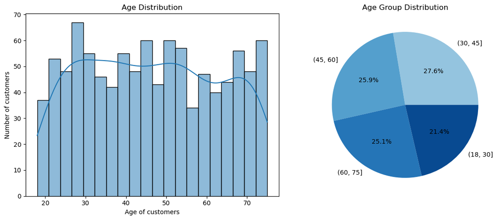

```python
fig, ax = plt.subplots(1, 2, figsize=(12, 5))

# 🔹 Pie Chart (using Age groups)
age_groups = pd.cut(customer['Age'], bins=[18,30,45,60,75])
age_counts = age_groups.value_counts()
cmap = plt.get_cmap('Blues')
colors = cmap(np.linspace(0.4, 0.9, len(age_counts)))
ax[1].pie(age_counts, labels=age_counts.index, autopct='%1.1f%%', colors=colors)
ax[1].set_title("Age Group Distribution")

# 🔹 Histogram
sns.histplot(customer['Age'], bins=20, kde=True, ax=ax[0])

ax[0].set_title("Age Distribution")
ax[0].set_xlabel("Age of customers")
ax[0].set_ylabel("Number of customers")

plt.tight_layout()
plt.show()
```

**Age Distribution Insights :**

The age distribution of customers appears to be relatively uniform across different age groups, with no extreme peaks or strong skewness. Customers are spread across a wide age range (approximately 18 to 75 years), indicating a diverse customer base. There are slight concentrations observed in the age groups around 25–35 and 45–55, but overall the distribution remains fairly balanced.

**Business Insights :**

The uniform distribution suggests that the company caters to a broad audience rather than a specific age segment. This presents opportunities to:

- Develop **segment-specific marketing strategies** targeting different age groups.
- Create **personalized product offerings** for younger, middle-aged, and older customers.
- Avoid over-reliance on a single demographic, reducing business risk.
- Explore targeted campaigns to strengthen engagement in slightly underrepresented age brackets.

**Question 2:** How many customers belong to each gender category?

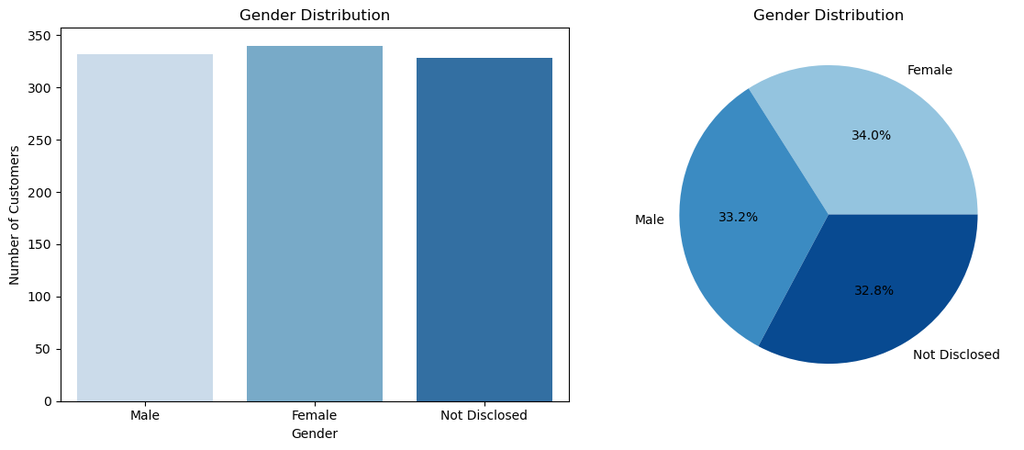

```python
gender_counts = customer["Gender"].value_counts()

fig, ax = plt.subplots(1, 2, figsize=(12, 5))

# 🔹 Countplot
sns.countplot(x='Gender', data=customer, ax=ax[0], palette='Blues')

ax[0].set_title("Gender Distribution")
ax[0].set_xlabel("Gender")
ax[0].set_ylabel("Number of Customers")


# 🔹 Pie Chart
cmap = plt.get_cmap('Blues')
colors = cmap(np.linspace(0.4, 0.9, len(gender_counts)))  # light → dark blue shades

ax[1].pie(gender_counts.values,
          labels=gender_counts.index,
          autopct='%1.1f%%',
          colors=colors)

ax[1].set_title("Gender Distribution")

plt.tight_layout()
plt.show()
```

**Gender Distribution Insights :**

The gender distribution of customers is highly balanced across all categories, with Female customers slightly leading, followed closely by Male and Not Disclosed groups. The differences between categories are minimal, indicating no significant skew toward any particular gender.

**Business Insights :**

The balanced gender distribution suggests that the company’s products or services appeal equally to a diverse audience. This creates opportunities to:

- Design **inclusive marketing campaigns** targeting all gender groups.
- Avoid bias toward a specific segment, ensuring broader market reach.
- Explore personalization strategies based on behavior rather than relying solely on gender.
- Further analyze the “Not Disclosed” segment to better understand their preferences and engagement patterns.

Bivariate Analysis

**Question 1:** How does age distribution vary across different marital status groups?

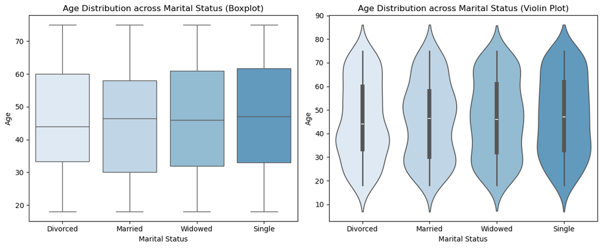

```python
palette = sns.color_palette("Blues")

fig, ax = plt.subplots(1, 2, figsize=(12, 5))

# 🔹 Boxplot
sns.boxplot(x='MaritalStatus', y='Age',data=customer, palette=palette,ax=ax[0])

ax[0].set_title("Age Distribution across Marital Status (Boxplot)")
ax[0].set_xlabel("Marital Status")
ax[0].set_ylabel("Age")


# 🔹 Violin Plot
sns.violinplot(x='MaritalStatus',  y='Age',  data=customer,  palette=palette,ax=ax[1])

ax[1].set_title("Age Distribution across Marital Status (Violin Plot)")
ax[1].set_xlabel("Marital Status")
ax[1].set_ylabel("Age")


plt.tight_layout()
plt.show()
```

Multivariate Analysis

**Question 1:** How does the relationship between age and number of children vary across different genders?

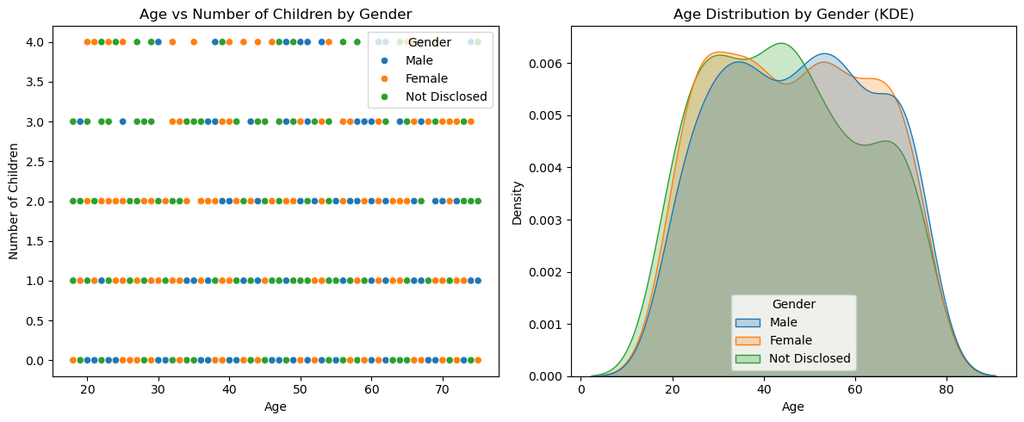

```python
fig, ax = plt.subplots(1, 2, figsize=(12, 5))

# 🔹 Scatter Plot
sns.scatterplot( x='Age',  y='NumChildren',  hue='Gender',  data=customer, ax=ax[0])

ax[0].set_title("Age vs Number of Children by Gender")
ax[0].set_xlabel("Age")
ax[0].set_ylabel("Number of Children")


# 🔹 KDE Plot (Density of Age)
sns.kdeplot( data=customer, x='Age', hue='Gender', fill=True, ax=ax[1])

ax[1].set_title("Age Distribution by Gender (KDE)")
ax[1].set_xlabel("Age")
ax[1].set_ylabel("Density")


plt.tight_layout()
plt.show()
```

**Insights from the Visualization :**

- The scatter plot shows that the number of children is fairly evenly distributed across all age groups, with most customers having between 0 to 3 children regardless of age.
- There is no strong correlation between age and number of children, indicating that family size does not significantly increase with age in this dataset.
- Gender-wise distribution appears consistent, with no major variation in the number of children across Male, Female, and Not Disclosed categories.

**Business Insights :**

- Since family size is not strongly dependent on age or gender, marketing strategies based on number of children should be **broad rather than highly segmented**.
- Products or offers targeting families (e.g., bundles, family discounts) can be promoted across **all age groups and genders**.
- The similar age distribution across genders suggests that **age-based targeting strategies can be applied uniformly** without heavy gender-specific customization.

EDA OF CUSTOMER TRANSACTION DATA

Univariate Analysis

**Question 1:** What is the distribution of transaction amounts?

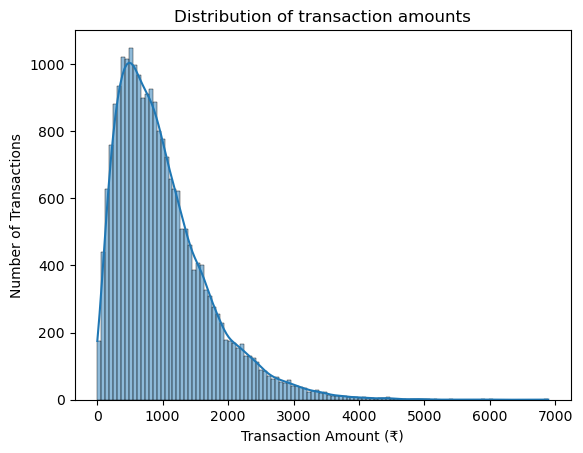

```python
sns.histplot(transaction["TransactionAmount"], bins= 'fd', kde= True)

plt.title('Distribution of transaction amounts')
plt.xlabel('Transaction Amount (₹)')
plt.ylabel('Number of Transactions')

plt.show()
```

**Univariate Analysis:**

- The histogram shows that most transactions are concentrated within a specific range, indicating a common spending pattern among customers.
- The distribution appears slightly right-skewed, suggesting the presence of some high-value transactions, but they are relatively less frequent.
- A majority of transactions are of lower to moderate value, while high transaction amounts occur less often.

**Business Insights :**

- Since most customers make low to mid-value purchases, the company can focus on **upselling and cross-selling strategies** to increase the average transaction value.
- High-value transactions, although fewer, indicate the presence of **premium customers**, which can be targeted with exclusive offers or loyalty programs.
- The spending pattern suggests an opportunity to introduce **bundle deals or discounts** to encourage customers to spend more per transaction.

Bivariate Analysis

**Question 1:** How does transaction amount vary over time?

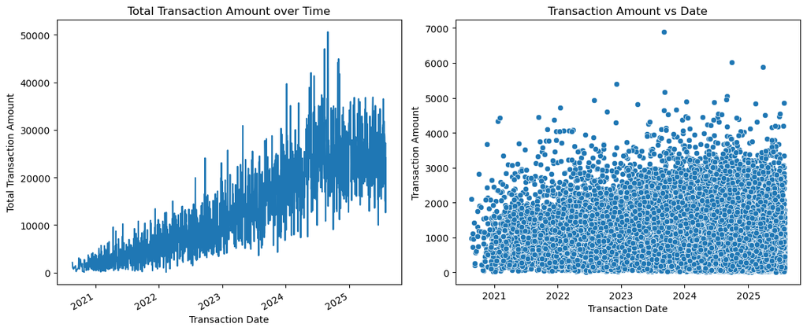

```python
fig, ax = plt.subplots(1, 2, figsize=(12, 5))

# Line Plot
transaction.groupby('TransactionDate')['TransactionAmount'].sum().plot(ax=ax[0])

ax[0].set_title("Total Transaction Amount over Time")
ax[0].set_xlabel("Transaction Date")
ax[0].set_ylabel("Total Transaction Amount")

# Scatter Plot
sns.scatterplot(x='TransactionDate', y='TransactionAmount', data=transaction, ax=ax[1])

ax[1].set_title("Transaction Amount vs Date")
ax[1].set_xlabel("Transaction Date")
ax[1].set_ylabel("Transaction Amount")

plt.tight_layout()
plt.show()
```

**Bivariate Analysis:**

- The line plot shows a clear upward trend in total transaction amount over time, indicating steady growth in overall business revenue.
- The scatter plot highlights that most transactions are concentrated in the lower to mid-value range, with occasional high-value transactions acting as outliers.
- As time progresses, the density of transactions increases, suggesting higher customer activity and purchase frequency.

**Business Insights:**

- The consistent growth trend reflects improving business performance and provides an opportunity to scale operations and marketing efforts.
- Since most purchases are moderate in value, strategies such as **upselling and cross-selling** can help increase revenue per transaction.
- The presence of high-value outliers indicates potential **premium customers**, who can be targeted with exclusive offers and loyalty programs.

Multivariate Analysis

**Question 1:** How do transaction amounts vary over time across different customers?

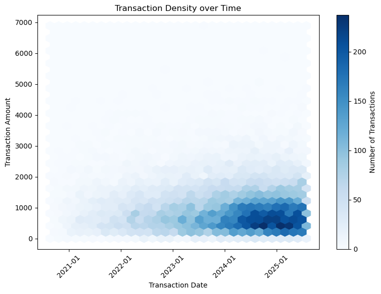

```python
import matplotlib.dates as mdates

x_dates = mdates.date2num(transaction['TransactionDate'])

plt.figure(figsize=(8,6))

hb = plt.hexbin(x_dates,transaction['TransactionAmount'],gridsize=30,cmap='Blues')


plt.colorbar(hb, label='Number of Transactions')


plt.gca().xaxis_date()
plt.gca().xaxis.set_major_formatter(mdates.DateFormatter('%Y-%m'))

plt.title("Transaction Density over Time")
plt.xlabel("Transaction Date")
plt.ylabel("Transaction Amount")

plt.xticks(rotation=45)
plt.tight_layout()
plt.show()
```

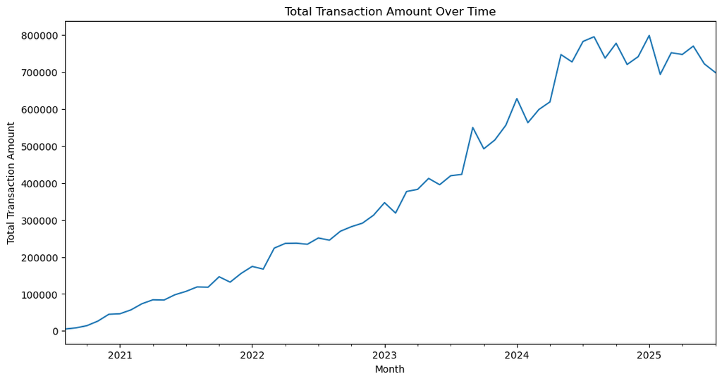

```python
transaction['Month'] = transaction['TransactionDate'].dt.to_period('M')

monthly = transaction.groupby('Month')['TransactionAmount'].sum()

plt.figure(figsize=(12,6))
monthly.plot()

plt.title("Total Transaction Amount Over Time")
plt.xlabel("Month")
plt.ylabel("Total Transaction Amount")


plt.show()
```

**Multivariate Analysis:**

- The line plot shows a clear upward trend in total transaction amount over time, indicating strong business growth and increasing customer spending.
- The hexbin plot reveals that most transactions are concentrated in the lower to mid-value range, with high-value transactions occurring less frequently.
- Over time, transaction density increases significantly, suggesting higher customer engagement and transaction volume in recent periods.

**Business Insights:**

- The consistent growth trend indicates a positive business trajectory, making it a good opportunity to scale marketing and operations.
- Since most transactions are of moderate value, strategies like **upselling and bundling** can help increase average transaction value.
- The increasing transaction density in recent years suggests improved customer activity, which can be leveraged through **loyalty programs and retention strategies**.

RFM ANALYSIS

**Merging the two datasets :** In order to calculate & analyse the recency, frequency and monetary factors of the customers from the data we have to merge the datasets so that the transaction and customer master informations could give us more impactful insights about the business.

```python
# inner-join

df_inner= pd.merge(transaction, customer, on="CustomerID", how="inner")
df_inner.info()
```

```
<class 'pandas.core.frame.DataFrame'>
RangeIndex: 23050 entries, 0 to 23049
Data columns (total 12 columns):
 #   Column             Non-Null Count  Dtype
---  ------             --------------  -----
 0   CustomerID         23050 non-null  object
 1   TransactionDate    23050 non-null  datetime64[ns]
 2   TransactionAmount  23050 non-null  float64
 3   Month              23050 non-null  period[M]
 4   Name               23050 non-null  object
 5   Email              23050 non-null  object
 6   Gender             23050 non-null  object
 7   Age                23050 non-null  int64
 8   City               23050 non-null  object
 9   MaritalStatus      23050 non-null  object
 10  NumChildren        23050 non-null  int64
 11  JoinDate           23050 non-null  datetime64[ns]
dtypes: datetime64[ns](2), float64(1), int64(2), object(6), period[M](1)
memory usage: 2.1+ MB
```

```python
print(df_inner.shape)
```

```
(23050, 12)
```

```python
df_inner["CustomerID"].describe()
```

```
count         23050
unique         1000
top       CUST10851
freq             38
Name: CustomerID, dtype: object
```

```python
# Left Join
df_left= pd.merge(transaction, customer, on="CustomerID", how="left")
df_left.info()
```

```
<class 'pandas.core.frame.DataFrame'>
RangeIndex: 23050 entries, 0 to 23049
Data columns (total 12 columns):
 #   Column             Non-Null Count  Dtype
---  ------             --------------  -----
 0   CustomerID         23050 non-null  object
 1   TransactionDate    23050 non-null  datetime64[ns]
 2   TransactionAmount  23050 non-null  float64
 3   Month              23050 non-null  period[M]
 4   Name               23050 non-null  object
 5   Email              23050 non-null  object
 6   Gender             23050 non-null  object
 7   Age                23050 non-null  int64
 8   City               23050 non-null  object
 9   MaritalStatus      23050 non-null  object
 10  NumChildren        23050 non-null  int64
 11  JoinDate           23050 non-null  datetime64[ns]
dtypes: datetime64[ns](2), float64(1), int64(2), object(6), period[M](1)
memory usage: 2.1+ MB
```

```python
print(df_left.shape)
```

```
(23050, 12)
```

**RFM Calculation :**

```python
# Take max date and manually add 1 day
reference_date = df_left['TransactionDate'].max()

# Add 1 day manually
reference_date = reference_date + pd.DateOffset(days=1)

reference_date
```

```
Timestamp('2025-07-30 00:00:00')
```

```python
# Recency (last purchase date)
recency_df = df_left.groupby('CustomerID')['TransactionDate'].max().reset_index()

# Rename column
recency_df.columns = ['CustomerID', 'LastPurchaseDate']

# Calculate Recency (in days)
recency_df['Recency'] = (reference_date - recency_df['LastPurchaseDate']).dt.days
```

```python
recency_df.head()
```

|  | CustomerID | LastPurchaseDate | Recency |
| --- | --- | --- | --- |
| 0 | CUST10000 | 2025-07-17 | 13 |
| 1 | CUST10001 | 2025-06-25 | 35 |
| 2 | CUST10002 | 2025-07-12 | 18 |
| 3 | CUST10003 | 2025-05-10 | 81 |
| 4 | CUST10004 | 2025-07-22 | 8 |

```python
# Frequency (number of transactions)
frequency_df = df_left.groupby('CustomerID')['TransactionDate'].count().reset_index()
frequency_df.columns = ['CustomerID', 'Frequency']
```

```python
frequency_df.head()
```

|  | CustomerID | Frequency |
| --- | --- | --- |
| 0 | CUST10000 | 23 |
| 1 | CUST10001 | 30 |
| 2 | CUST10002 | 24 |
| 3 | CUST10003 | 25 |
| 4 | CUST10004 | 19 |

```python
# Monetary (total spend)
monetary_df = df_left.groupby('CustomerID')['TransactionAmount'].sum().reset_index()
monetary_df.columns = ['CustomerID', 'Monetary']
```

```python
monetary_df.head()
```

|  | CustomerID | Monetary |
| --- | --- | --- |
| 0 | CUST10000 | 21265.49 |
| 1 | CUST10001 | 28654.31 |
| 2 | CUST10002 | 23884.03 |
| 3 | CUST10003 | 24206.03 |
| 4 | CUST10004 | 25565.30 |

```python
# Merge all together
df_rfm = recency_df.merge(frequency_df, on='CustomerID')
df_rfm = df_rfm.merge(monetary_df, on='CustomerID')

df_rfm.head()
```

|  | CustomerID | LastPurchaseDate | Recency | Frequency | Monetary |
| --- | --- | --- | --- | --- | --- |
| 0 | CUST10000 | 2025-07-17 | 13 | 23 | 21265.49 |
| 1 | CUST10001 | 2025-06-25 | 35 | 30 | 28654.31 |
| 2 | CUST10002 | 2025-07-12 | 18 | 24 | 23884.03 |
| 3 | CUST10003 | 2025-05-10 | 81 | 25 | 24206.03 |
| 4 | CUST10004 | 2025-07-22 | 8 | 19 | 25565.30 |

**Score RFM :**

```python
# Quantile-based scoring
df_rfm['R_Score'] = pd.qcut(df_rfm['Recency'], 5, labels=[5,4,3,2,1]).astype(int)
df_rfm['F_Score'] = pd.qcut(df_rfm['Frequency'], 5, labels=[1,2,3,4,5]).astype(int)
df_rfm['M_Score'] = pd.qcut(df_rfm['Monetary'], 5, labels=[1,2,3,4,5]).astype(int)

# Combined RFM
df_rfm['RFM_Segment'] = df_rfm['R_Score'].astype(str) + df_rfm['F_Score'].astype(str) + df_rfm['M_Score'].astype(str)
df_rfm['RFM_Score'] = df_rfm[['R_Score','F_Score','M_Score']].sum(axis=1)
```

```python
df_rfm.head()
```

[output not shown]

```python
df_rfm.tail()
```

[output not shown]

**Assigning Segment Labels :**

```python
def segment(row):
    if row['RFM_Segment'] == '555':
        return 'Champion'
    elif row['R_Score'] >= 4 and row['F_Score'] >= 4:
        return 'Loyal Customer'
    elif row['R_Score'] >= 4 and row['F_Score'] <= 3:
        return 'Potential Loyalist'
    elif row['R_Score'] <= 2 and row['F_Score'] >= 3:
        return 'At Risk'
    elif row['R_Score'] == 1 and row['F_Score'] <= 2:
        return 'Lost'
    elif row['M_Score'] >= 4:
        return 'Big Spender'
    else:
        return 'Others'

df_rfm['Segment'] = df_rfm.apply(segment, axis=1)
```

```python
df_rfm.head()
```

|  | CustomerID | LastPurchaseDate | Recency | Frequency | Monetary | R_Score | F_Score | M_Score | RFM_Score | Segment | RFM_Segment |
| --- | --- | --- | --- | --- | --- | --- | --- | --- | --- | --- | --- |
| 0 | CUST10000 | 2025-07-17 | 13 | 23 | 21265.49 | 4 | 3 | 2 | 9 | Potential Loyalist | 432 |
| 1 | CUST10001 | 2025-06-25 | 35 | 30 | 28654.31 | 3 | 5 | 5 | 13 | Big Spender | 355 |
| 2 | CUST10002 | 2025-07-12 | 18 | 24 | 23884.03 | 4 | 3 | 3 | 10 | Potential Loyalist | 433 |
| 3 | CUST10003 | 2025-05-10 | 81 | 25 | 24206.03 | 1 | 4 | 3 | 8 | At Risk | 143 |
| 4 | CUST10004 | 2025-07-22 | 8 | 19 | 25565.30 | 5 | 1 | 4 | 10 | Potential Loyalist | 514 |

```python
df_rfm.tail()
```

|  | CustomerID | LastPurchaseDate | Recency | Frequency | Monetary | R_Score | F_Score | M_Score | RFM_Score | Segment | RFM_Segment |
| --- | --- | --- | --- | --- | --- | --- | --- | --- | --- | --- | --- |
| 995 | CUST10995 | 2024-06-23 | 402 | 21 | 24325.19 | 1 | 2 | 3 | 6 | Lost | 123 |
| 996 | CUST10996 | 2025-07-15 | 15 | 21 | 21809.11 | 4 | 2 | 3 | 9 | Potential Loyalist | 423 |
| 997 | CUST10997 | 2025-06-28 | 32 | 20 | 21120.48 | 3 | 2 | 2 | 7 | Others | 322 |
| 998 | CUST10998 | 2025-03-26 | 126 | 25 | 29494.56 | 1 | 4 | 5 | 10 | At Risk | 145 |
| 999 | CUST10999 | 2025-07-25 | 5 | 23 | 22028.01 | 5 | 3 | 3 | 11 | Potential Loyalist | 533 |

**Visualization of Insights :**

**1 :** Count of customers in each segment.

```python
df_rfm.Segment.value_counts()
```

```
Segment
Potential Loyalist    252
At Risk               207
Others                181
Loyal Customer        122
Lost                  105
Big Spender            98
Champion               35
Name: count, dtype: int64
```

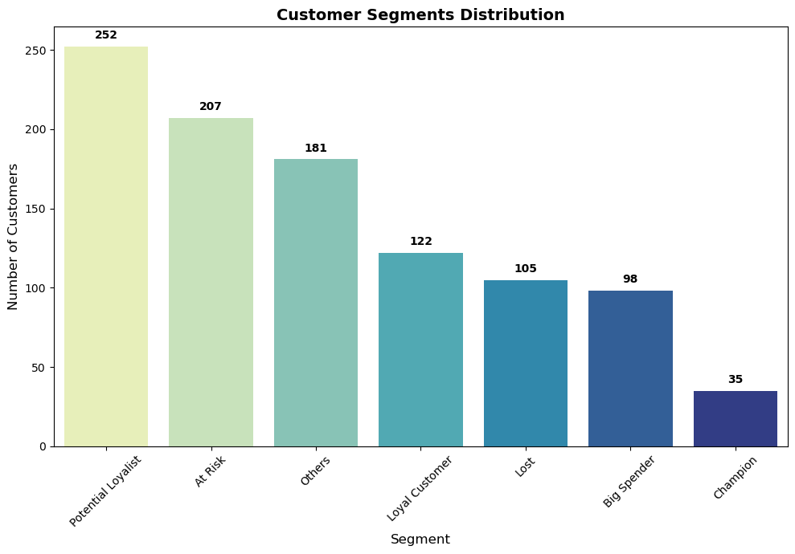

```python
segment_counts = df_rfm['Segment'].value_counts().sort_values(ascending=False)

plt.figure(figsize=(10,7))

sns.barplot(x=segment_counts.index,y=segment_counts.values,palette="YlGnBu")

# 🔹 Add labels on top of bars
for i, val in enumerate(segment_counts.values):
    plt.text(i, val + 5, str(val), ha='center', fontsize=10, fontweight='bold')

plt.title("Customer Segments Distribution", fontsize=14, fontweight='bold')
plt.xlabel("Segment", fontsize=12)
plt.ylabel("Number of Customers", fontsize=12)

plt.xticks(rotation=45)

plt.tight_layout()
plt.show()
```

Insights from Customer Segmentation :

- The largest segment consists of **Potential Loyalists**, indicating a strong base of customers who are actively engaging but have not yet reached full loyalty.
- A significant number of customers fall under the **At Risk** and **Lost** categories, highlighting potential churn and disengagement concerns.
- The relatively smaller proportion of **Champions** suggests that only a limited group of customers contribute consistently at the highest level.
- The presence of **Big Spenders** and **Loyal Customers** reflects a valuable segment that contributes significantly to revenue.

Business Insights :

- **Focus on conversion:** Potential Loyalists should be targeted with personalized offers, loyalty programs, and engagement campaigns to convert them into **Loyal Customers or Champions**.
- **Reduce churn risk:** Customers in the *At Risk* and *Lost* segments should be re-engaged through targeted campaigns such as discounts, reminders, or win-back strategies.
- **Reward high-value customers:** Champions and Big Spenders should be retained through exclusive benefits, early access offers, and premium experiences.
- **Segment-based marketing:** Tailoring marketing strategies based on customer segments can significantly improve retention, engagement, and overall revenue growth.

**2 :** Revenue contribution per segment.

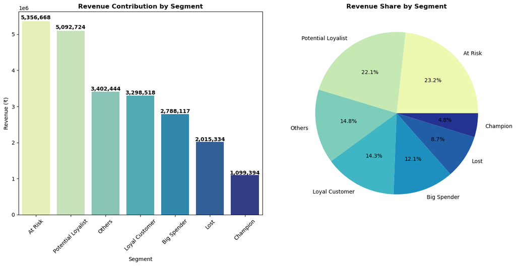

```python
# 🔹 Prepare data
segment_revenue = (df_rfm.groupby('Segment')['Monetary'].sum().sort_values(ascending=False))

# 🔹 Create subplots
fig, ax = plt.subplots(1, 2, figsize=(14,7))

# 🔹 Bar Plot
sns.barplot(x=segment_revenue.index,y=segment_revenue.values,palette="YlGnBu",ax=ax[0])

# Add labels
for i, val in enumerate(segment_revenue.values):
    ax[0].text(i, val + val*0.01, f"{val:,.0f}", ha='center', fontsize=10, fontweight='bold')

ax[0].set_title("Revenue Contribution by Segment", fontweight='bold')
ax[0].set_xlabel("Segment")
ax[0].set_ylabel("Revenue (₹)")
ax[0].tick_params(axis='x', rotation=45)

# 🔹 Pie Chart
colors = sns.color_palette("YlGnBu", len(segment_revenue))

ax[1].pie(segment_revenue.values,labels=segment_revenue.index,autopct='%1.1f%%',colors=colors)

ax[1].set_title("Revenue Share by Segment", fontweight='bold')

# 🔹 Layout
plt.tight_layout()
plt.show()
```

**Insights from Revenue Contribution by Segment**

- A significant portion of total revenue is generated by **Potential Loyalists**, indicating a large and active customer base with strong purchasing behavior.
- **Loyal Customers and Big Spenders** contribute substantially to overall revenue despite being smaller in number, highlighting their high individual value.
- The presence of notable revenue from **At Risk** customers suggests that previously valuable customers are at risk of churn.
- **Champions**, although fewer in count, represent highly valuable customers with consistent and high spending patterns.

**Business Insights & Recommendations:**

- **Maximize conversion opportunities:** Potential Loyalists should be nurtured through targeted engagement to convert them into **Loyal Customers or Champions**, unlocking higher lifetime value.
- **Retain high-value segments:** Loyal Customers, Big Spenders, and Champions should be prioritized with exclusive rewards, personalized offers, and loyalty programs.
- **Re-engage At Risk customers:** Since they still contribute significantly to revenue, timely intervention strategies such as discounts or personalized campaigns can prevent revenue loss.
- **Optimize marketing focus:** Instead of treating all customers equally, a segment-based strategy can help allocate resources efficiently and maximize revenue growth.

**3 :** Recency vs Montary scatter plot colored by segment.

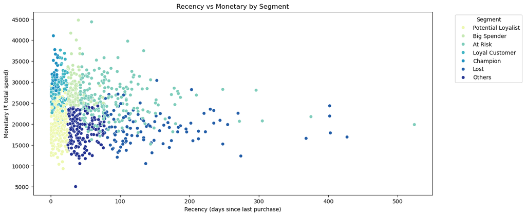

```python
plt.figure(figsize=(13,6))

sns.scatterplot(data=df_rfm, x='Recency', y='Monetary', hue='Segment', palette='YlGnBu')

plt.title("Recency vs Monetary by Segment")
plt.xlabel("Recency (days since last purchase)")
plt.ylabel("Monetary (₹ total spend)")
plt.legend(title="Segment", bbox_to_anchor=(1.05, 1), loc='upper left')
plt.show()
```

**Insights from Recency vs Monetary Analysis**

- Customers with **low recency and high monetary value** form a dense cluster, indicating a strong base of recently active, high-value customers driving current revenue.
- As recency increases, the overall monetary contribution tends to decline, highlighting reduced engagement from customers who haven’t purchased recently.
- A noticeable spread of customers exists in the **high recency but moderate-to-high monetary range**, representing previously valuable customers who are now at risk of churn.
- The distribution suggests that high spending is more common among recently active customers, reinforcing the importance of continuous engagement.

**Business Insights & Recommendations**

- **Strengthen retention strategies:** Recently active high spenders should be nurtured through loyalty programs and personalized experiences.
- **Target churn-prone customers:** Customers with high past spending but high recency should be prioritized for win-back campaigns.
- **Improve engagement cycles:** Regular touchpoints such as offers and reminders can help reduce recency and maintain customer activity.
- **Maximize lifetime value:** Encouraging repeat purchases from mid-value customers can help shift them toward higher monetary segments.

**4 :** Pareto Analysis: Show how top 20% of customers contribute to 80% revenue.

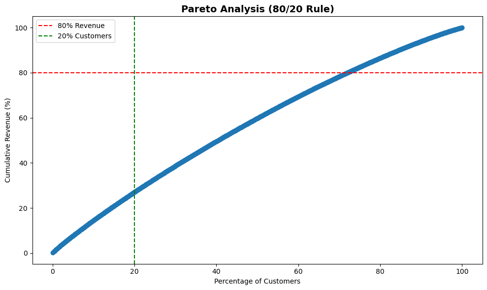

```python
# 🔹 Step 1: Revenue per customer
customer_revenue = (
    df_rfm.groupby('CustomerID')['Monetary']
    .sum()
    .sort_values(ascending=False)
)

# 🔹 Step 2: Cumulative revenue %
cum_revenue = customer_revenue.cumsum()
cum_percentage = 100 * cum_revenue / cum_revenue.iloc[-1]

# 🔹 Step 3: Customer %
customer_percentage = np.arange(1, len(customer_revenue)+1) / len(customer_revenue) * 100

# 🔹 Step 4: Plot
plt.figure(figsize=(10,6))

plt.plot(customer_percentage, cum_percentage, marker='o')

# Reference lines
plt.axhline(80, color='red', linestyle='--', label='80% Revenue')
plt.axvline(20, color='green', linestyle='--', label='20% Customers')

plt.title("Pareto Analysis (80/20 Rule)", fontsize=14, fontweight='bold')
plt.xlabel("Percentage of Customers")
plt.ylabel("Cumulative Revenue (%)")

plt.legend()

plt.tight_layout()
plt.show()
```

**Business Insights & Recommendations :**

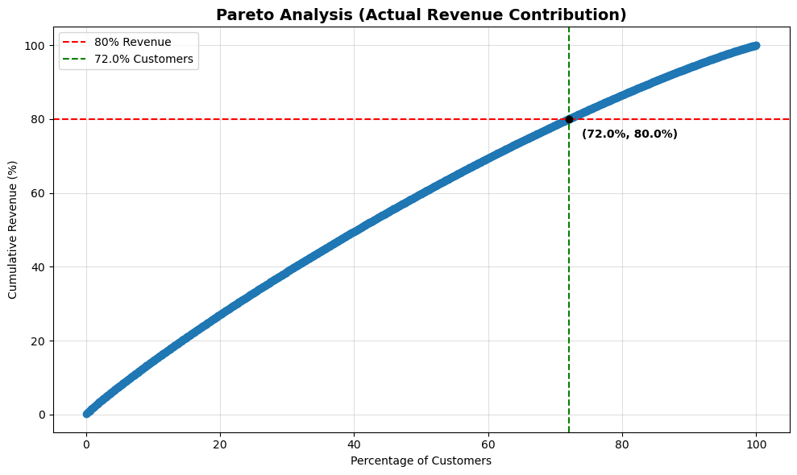

```python
# 🔹 Step 1: Revenue per customer
customer_revenue = (
    df_rfm.groupby('CustomerID')['Monetary']
    .sum()
    .sort_values(ascending=False)
)

# 🔹 Step 2: Cumulative revenue %
cum_revenue = customer_revenue.cumsum()
cum_percentage = 100 * cum_revenue / cum_revenue.iloc[-1]

# 🔹 Step 3: Customer %
customer_percentage = np.arange(1, len(customer_revenue)+1) / len(customer_revenue) * 100

# 🔹 Step 4: Find exact point where revenue crosses 80%
idx_80 = np.where(cum_percentage >= 80)[0][0]
cust_pct_80 = customer_percentage[idx_80]
rev_pct_80 = cum_percentage.iloc[idx_80]

# 🔹 Step 5: Plot
plt.figure(figsize=(10,6))

plt.plot(customer_percentage, cum_percentage, marker='o')

# Reference lines
plt.axhline(80, color='red', linestyle='--', label='80% Revenue')
plt.axvline(cust_pct_80, color='green', linestyle='--', label=f'{cust_pct_80:.1f}% Customers')

# Highlight exact point
plt.scatter(cust_pct_80, rev_pct_80, color='black', zorder=5)

# Annotation
plt.text(
    cust_pct_80 + 2, rev_pct_80 - 5,
    f'({cust_pct_80:.1f}%, {rev_pct_80:.1f}%)',
    fontsize=10,
    fontweight='bold'
)

plt.title("Pareto Analysis (Actual Revenue Contribution)", fontsize=14, fontweight='bold')
plt.xlabel("Percentage of Customers")
plt.ylabel("Cumulative Revenue (%)")

plt.legend()
plt.grid(alpha=0.4)

plt.tight_layout()
plt.show()
```

**Pareto Analysis (Actual Revenue Contribution):**

The Pareto analysis reveals that approximately **72% of customers contribute to 80% of the total revenue**, indicating that the traditional 80/20 rule does not strictly apply to this dataset.

The cumulative revenue curve shows a gradual increase rather than a steep rise, suggesting that revenue is relatively distributed across a broader customer base rather than being concentrated among a small group of top customers.

**Business Insights & Recommendations:**

- **Balanced revenue distribution:** The business is not heavily dependent on a small group of customers, reducing the risk associated with customer churn.
- **Opportunity to build high-value segments:** Since revenue is spread out, there is potential to identify and nurture customers into high-value segments like Champions or Loyal Customers.
- **Focus on overall engagement:** Strategies should target the wider customer base rather than only top-tier customers to drive consistent growth.
- **Enhance customer value:** Upselling and cross-selling strategies can help increase the contribution of mid-tier customers and improve overall revenue concentration.

FINAL DASHBOARD

```python
df_rfm['Recency'].mean()
```

```
np.float64(50.794)
```

```python
transaction.groupby('CustomerID')['TransactionAmount'].sum().mean()
```

```
np.float64(23053.19966)
```

### 📌 Key Metrics

- 👥 Total Customers: **1000**
- 💰 Total Revenue: **₹ 2,30,53,199.66**
- 📅 Average Recency: **50.794 days**
- 🛒 Average Spend per Customer: **₹ 23053.19966**

### 👥 Customer Segmentation Insights

- Majority of customers fall under **Potential Loyalists**, indicating strong growth potential.
- A significant portion of customers are **At Risk or Lost**, highlighting churn concerns.
- High-value segments like **Champions and Loyal Customers** contribute significantly despite smaller size.

👉 Focus: Convert potential customers & retain high-value users.

👉 Focus: Upsell and strengthen customer lifetime value.

### 📊 RFM Insights (Recency, Frequency, Monetary)

- Customers with **low recency & high spend** are the most valuable (Champions).
- High recency customers indicate **churn risk**, even if past spending was high.
- Potential Loyalists can be converted into high-value customers with proper engagement.

👉 Focus: Retention + Re-engagement strategies.

### 📈 Pareto Analysis (Final Insight)

- Approximately **72% of customers contribute to 80% of revenue**, indicating a **broad revenue distribution**.
- The business is not overly dependent on a small group of customers.

👉 Focus: Balanced growth strategy across all customer segments.

## 🚀 Final Insights & Business Recommendations

### 📊 Key findings

- The customer base is **diverse and well-distributed** across different demographics and cities.
- A large portion of customers falls under **Potential Loyalists**, indicating strong future growth potential.
- High-value segments such as **Champions, Loyal Customers, and Big Spenders** contribute significantly to total revenue despite being smaller in number.
- The **Recency vs Monetary analysis** highlights that recently active customers tend to generate higher revenue.
- Pareto analysis shows that **72% of customers contribute to 80% of revenue**, indicating a relatively **balanced revenue distribution**.

### 🎯 Business Recommendations:

- **Customer Retention:** Focus on retaining high-value customers through loyalty programs and personalized offers.
- **Customer Conversion:** Convert Potential Loyalists into Loyal Customers using targeted marketing strategies.
- **Churn Prevention:** Re-engage At Risk and Lost customers through special campaigns and incentives.
- **Revenue Growth:** Encourage mid-tier customers to increase spending through upselling and cross-selling.
- **Marketing Strategy:** Adopt a **segment-based marketing approach** rather than a one-size-fits-all strategy.

### 🎯 Final Conclusion

This analysis demonstrates that the business has a **strong foundation with balanced customer distribution and growth opportunities**. By focusing on customer segmentation and targeted engagement strategies, the company can significantly enhance customer lifetime value and overall profitability.